# Construct Non-Hierarchical P/NBD Model for Online Retail Transaction Data

Author

Mick Cooney mickcooney@gmail.com

Published

May 18, 2023

# 1 Load and Construct Datasets

```r
use_fit_start_date <- as.Date("2009-12-01")
use_fit_end_date   <- as.Date("2010-12-01")

use_valid_start_date <- as.Date("2010-12-01")
use_valid_end_date   <- as.Date("2012-12-10")
```

## 1.1 Load Online Retail Transaction Data

We now want to load the online retail transaction data.

```r
customer_cohortdata_tbl <- read_rds("data/onlineretail_cohort_tbl.rds")
customer_cohortdata_tbl |> glimpse()
```

```
Rows: 5,852
Columns: 5
$ customer_id     <chr> "12346", "12347", "12348", "12349", "12350", "12351", …
$ cohort_qtr      <chr> "2010 Q1", "2010 Q4", "2010 Q3", "2010 Q2", "2011 Q1",…
$ cohort_ym       <chr> "2010 03", "2010 10", "2010 09", "2010 04", "2011 02",…
$ first_tnx_date  <date> 2010-03-02, 2010-10-31, 2010-09-27, 2010-04-29, 2011-…
$ total_tnx_count <int> 3, 8, 5, 3, 1, 1, 9, 2, 1, 2, 6, 2, 5, 10, 6, 4, 10, 2…
```

```r
customer_transactions_tbl <- read_rds("data/onlineretail_transactions_tbl.rds")
customer_transactions_tbl |> glimpse()
```

```
Rows: 53,711
Columns: 4
$ tnx_timestamp <dttm> 2009-12-01 07:45:00, 2009-12-01 07:45:59, 2009-12-01 09…
$ invoice_id    <chr> "489434", "489435", "489436", "489437", "489438", "48943…
$ customer_id   <chr> "13085", "13085", "13078", "15362", "18102", "12682", "1…
$ tnx_amount    <dbl> 505.30, 145.80, 630.33, 310.75, 2286.24, 426.30, 50.40, …
```

We re-produce the visualisation of the transaction times we used in previous workbooks.

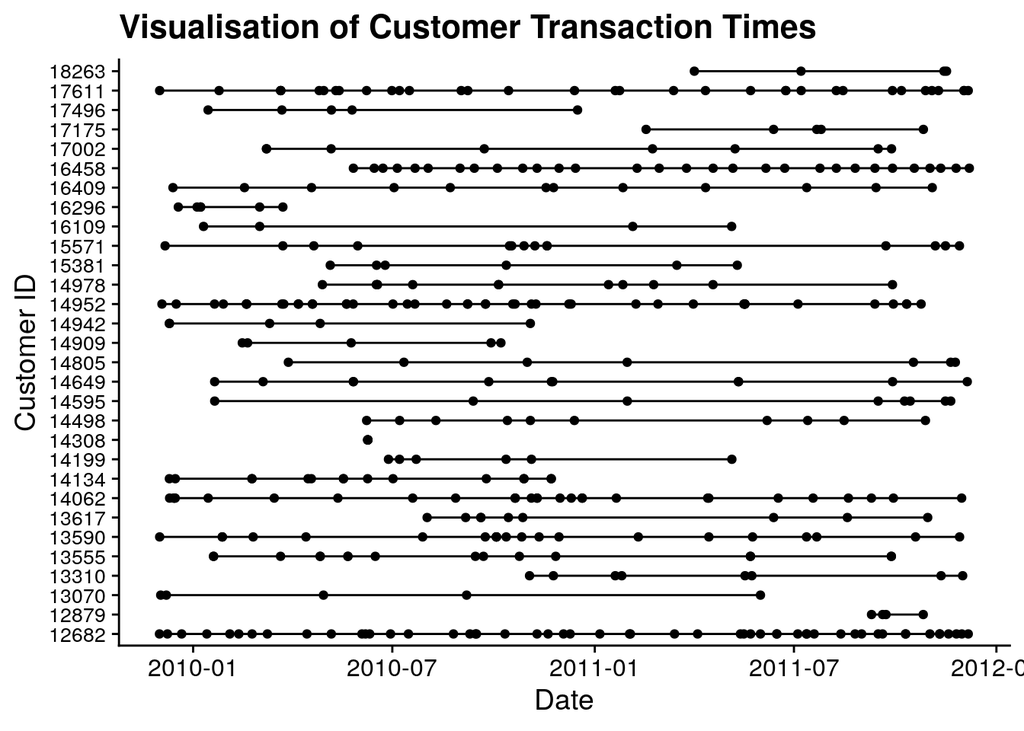

```r
plot_tbl <- customer_transactions_tbl |>
  group_nest(customer_id, .key = "cust_data") |>
  filter(map_int(cust_data, nrow) > 3) |>
  slice_sample(n = 30) |>
  unnest(cust_data)

ggplot(plot_tbl, aes(x = tnx_timestamp, y = customer_id)) +
  geom_line() +
  geom_point() +
  labs(
      x = "Date",
      y = "Customer ID",
      title = "Visualisation of Customer Transaction Times"
    ) +
  theme(axis.text.y = element_text(size = 10))
```

## 1.2 Construct Datasets

```r
customer_summarystats_tbl <- customer_transactions_tbl |>
  drop_na(customer_id) |>
  calculate_transaction_cbs_data(last_date = use_fit_end_date |> as.POSIXct())

customer_summarystats_tbl |> glimpse()
```

```
Rows: 4,336
Columns: 6
$ customer_id    <chr> "12346", "12347", "12348", "12349", "12351", "12352", "…
$ first_tnx_date <dttm> 2009-12-14 08:34:00, 2010-10-31 14:19:59, 2010-09-27 1…
$ last_tnx_date  <dttm> 2010-10-04 16:32:59, 2010-10-31 14:19:59, 2010-09-27 1…
$ x              <dbl> 14, 0, 0, 3, 0, 1, 0, 0, 2, 1, 2, 7, 5, 2, 0, 0, 0, 2, …
$ t_x            <dbl> 42.04751984, 0.00000000, 0.00000000, 46.83075397, 0.000…
$ T_cal          <dbl> 50.2347222, 4.3432540, 9.1965278, 51.6379960, 0.1941468…
```

As before, we construct a number of subsets of the data for use later on with the modelling and create some data subsets.

```r
customer_fit_stats_tbl <- customer_summarystats_tbl
customer_fit_stats_tbl |> glimpse()
```

```
Rows: 4,336
Columns: 6
$ customer_id    <chr> "12346", "12347", "12348", "12349", "12351", "12352", "…
$ first_tnx_date <dttm> 2009-12-14 08:34:00, 2010-10-31 14:19:59, 2010-09-27 1…
$ last_tnx_date  <dttm> 2010-10-04 16:32:59, 2010-10-31 14:19:59, 2010-09-27 1…
$ x              <dbl> 14, 0, 0, 3, 0, 1, 0, 0, 2, 1, 2, 7, 5, 2, 0, 0, 0, 2, …
$ t_x            <dbl> 42.04751984, 0.00000000, 0.00000000, 46.83075397, 0.000…
$ T_cal          <dbl> 50.2347222, 4.3432540, 9.1965278, 51.6379960, 0.1941468…
```

```r
customer_valid_stats_tbl <- customer_transactions_tbl |>
  drop_na(customer_id) |>
  filter(
    tnx_timestamp > (use_valid_start_date |> as.POSIXct())
    ) |>
  summarise(
    tnx_count = n(),
    tnx_last_interval = difftime(
        max(tnx_timestamp),
        use_valid_start_date,
        units = "weeks"
        ) |>
      as.numeric(),

    .by = customer_id
    )

customer_valid_stats_tbl |> glimpse()
```

```
Rows: 4,372
Columns: 3
$ customer_id       <chr> "17850", "13047", "12583", "13748", "15100", "15291"…
$ tnx_count         <int> 35, 18, 18, 5, 6, 20, 27, 15, 118, 86, 8, 1, 3, 76, …
$ tnx_last_interval <dbl> 10.22996032, 48.92956349, 53.04831349, 39.77232143, …
```

```r
obs_fitdata_tbl <- customer_fit_stats_tbl |>
  rename(tnx_count = x)


### We need to add all the zero count customers into the valid data
obs_validdata_tbl <- customer_fit_stats_tbl |>
  anti_join(customer_valid_stats_tbl, by = "customer_id") |>
  transmute(customer_id, tnx_count = 0) |>
  bind_rows(customer_valid_stats_tbl) |>
  arrange(customer_id)
```

We then write this data to disk.

```r
#! echo: TRUE

obs_fitdata_tbl   |> write_rds("data/onlineretail_obs_fitdata_tbl.rds")
obs_validdata_tbl |> write_rds("data/onlineretail_obs_validdata_tbl.rds")
```

# 2 Fit First P/NBD Model

Before we start on that, we set a few parameters for the workbook to organise our Stan code.

```r
stan_modeldir <- "stan_models"
stan_codedir  <-   "stan_code"
```

## 2.1 Compile and Fit Stan Model

We now compile this model using `CmdStanR`.

```r
pnbd_fixed_stanmodel <- cmdstan_model(
  "stan_code/pnbd_fixed.stan",
  include_paths =   stan_codedir,
  pedantic      =           TRUE,
  dir           =  stan_modeldir
  )
```

We then use this compiled model with our data to produce a fit of the data.

```r
stan_modelname <- "pnbd_onlineretail_fixed"
stanfit_seed   <- stanfit_seed + 1
stanfit_prefix <- str_c("fit_", stan_modelname)

stanfit_object_file <- glue("data/{stanfit_prefix}_stanfit.rds")

stan_data_lst <- customer_fit_stats_tbl |>
  select(customer_id, x, t_x, T_cal) |>
  compose_data(
    lambda_mn = 0.25,
    lambda_cv = 1.00,

    mu_mn     = 0.10,
    mu_cv     = 1.00,
    )

if(!file_exists(stanfit_object_file)) {
  pnbd_onlineretail_fixed1_stanfit <- pnbd_fixed_stanmodel$sample(
    data            =                stan_data_lst,
    chains          =                            4,
    iter_warmup     =                          500,
    iter_sampling   =                          500,
    seed            =                 stanfit_seed,
    save_warmup     =                         TRUE,
    output_dir      =                stan_modeldir,
    output_basename =               stanfit_prefix,
    )

  pnbd_onlineretail_fixed1_stanfit$save_object(stanfit_object_file)

} else {
  pnbd_onlineretail_fixed1_stanfit <- read_rds(stanfit_object_file)
}


pnbd_onlineretail_fixed1_stanfit$summary()
```

```
# A tibble: 13,009 × 10
   variable       mean   median      sd     mad       q5      q95  rhat ess_bulk
   <chr>         <num>    <num>   <num>   <num>    <num>    <num> <num>    <num>
 1 lp__       -7.51e+4 -7.51e+4 73.0    74.9    -7.52e+4 -7.50e+4 1.00      608.
 2 lambda[1]   2.90e-1  2.83e-1  0.0768  0.0722  1.74e-1  4.26e-1 0.999    2873.
 3 lambda[2]   1.52e-1  9.33e-2  0.175   0.104   5.54e-3  4.73e-1 1.00     2184.
 4 lambda[3]   1.34e-1  8.07e-2  0.156   0.0882  5.99e-3  4.49e-1 0.999    2602.
 5 lambda[4]   7.19e-2  6.63e-2  0.0370  0.0331  2.32e-2  1.41e-1 1.00     2457.
 6 lambda[5]   2.39e-1  1.73e-1  0.232   0.168   1.31e-2  7.05e-1 1.00     1422.
 7 lambda[6]   3.00e-1  2.54e-1  0.210   0.187   5.19e-2  7.11e-1 1.00     1673.
 8 lambda[7]   1.42e-1  9.30e-2  0.152   0.101   5.83e-3  4.35e-1 1.00     1875.
 9 lambda[8]   1.44e-1  8.09e-2  0.178   0.0919  5.50e-3  5.08e-1 1.00     1459.
10 lambda[9]   2.68e-1  2.40e-1  0.154   0.136   7.18e-2  5.57e-1 1.00     2853.
# ℹ 12,999 more rows
# ℹ 1 more variable: ess_tail <num>
```

We have some basic HMC-based validity statistics we can check.

```r
pnbd_onlineretail_fixed1_stanfit$cmdstan_diagnose()
```

```
Processing csv files: /home/rstudio/btydwork/stan_models/fit_pnbd_onlineretail_fixed-1.csvWarning: non-fatal error reading adaptation data
, /home/rstudio/btydwork/stan_models/fit_pnbd_onlineretail_fixed-2.csvWarning: non-fatal error reading adaptation data
, /home/rstudio/btydwork/stan_models/fit_pnbd_onlineretail_fixed-3.csvWarning: non-fatal error reading adaptation data
, /home/rstudio/btydwork/stan_models/fit_pnbd_onlineretail_fixed-4.csvWarning: non-fatal error reading adaptation data


Checking sampler transitions treedepth.
Treedepth satisfactory for all transitions.

Checking sampler transitions for divergences.
No divergent transitions found.

Checking E-BFMI - sampler transitions HMC potential energy.
E-BFMI satisfactory.

Effective sample size satisfactory.

Split R-hat values satisfactory all parameters.

Processing complete, no problems detected.
```

## 2.2 Visual Diagnostics of the Sample Validity

Now that we have a sample from the posterior distribution we need to create a few different visualisations of the diagnostics.

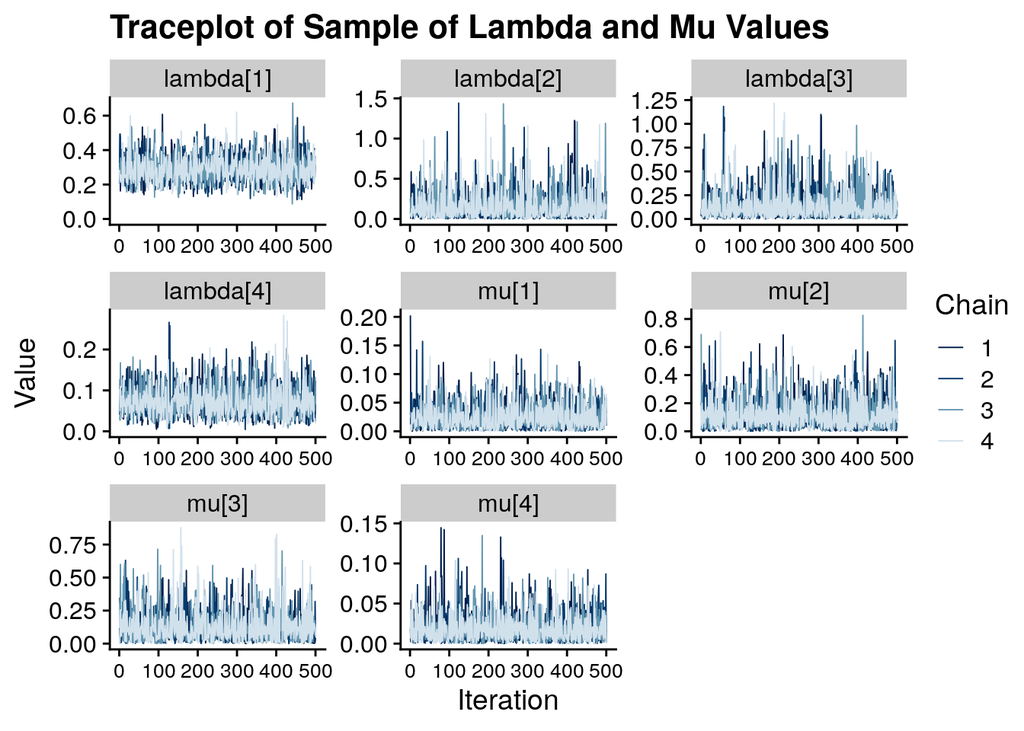

```r
parameter_subset <- c(
  "lambda[1]", "lambda[2]", "lambda[3]", "lambda[4]",
  "mu[1]",     "mu[2]",     "mu[3]",     "mu[4]"
  )

pnbd_onlineretail_fixed1_stanfit$draws(inc_warmup = FALSE) |>
  mcmc_trace(pars = parameter_subset) +
  expand_limits(y = 0) +
  labs(
    x = "Iteration",
    y = "Value",
    title = "Traceplot of Sample of Lambda and Mu Values"
    ) +
  theme(axis.text.x = element_text(size = 10))
```

We also check $N_{eff}$ as a quick diagnostic of the fit.

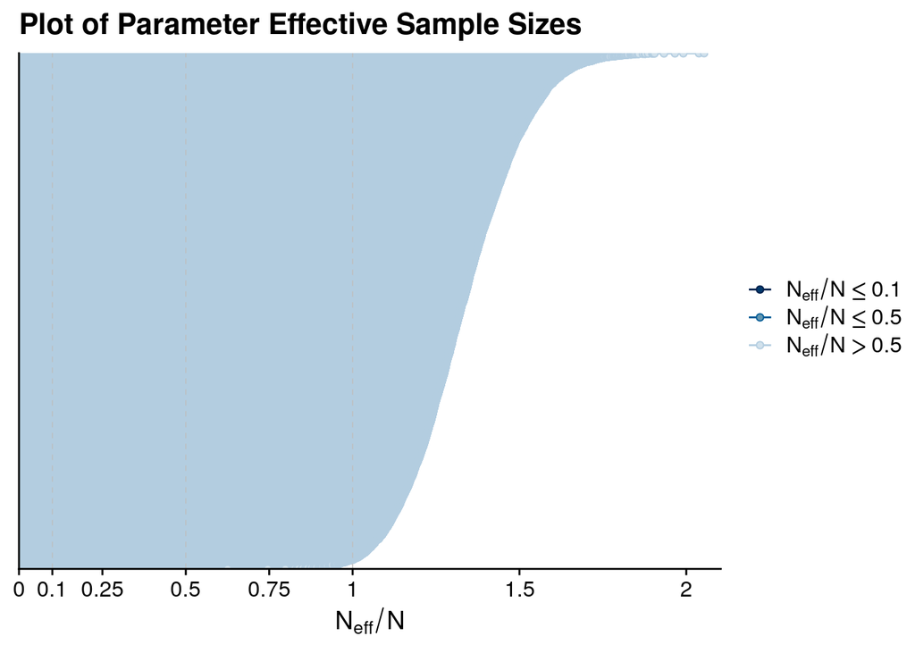

```r
pnbd_onlineretail_fixed1_stanfit |>
  neff_ratio(pars = c("lambda", "mu")) |>
  as.numeric() |>
  mcmc_neff() +
    ggtitle("Plot of Parameter Effective Sample Sizes")
```

## 2.3 Assess the Model

As we intend to run the same logic to assess each of our models, we have combined all this logic into a single function `run_model_assessment`, to run the simulations and combine the datasets.

```r
assess_data_lst <- run_model_assessment(
  model_stanfit    = pnbd_onlineretail_fixed1_stanfit,
  insample_tbl     = customer_fit_stats_tbl,
  outsample_tbl    = customer_valid_stats_tbl,
  fit_label        = "pnbd_onlineretail_fixed",
  fit_end_dttm     = use_fit_end_date     |> as.POSIXct(),
  valid_start_dttm = use_valid_start_date |> as.POSIXct(),
  valid_end_dttm   = use_valid_end_date   |> as.POSIXct(),
  sim_seed         = 10
  )

assess_data_lst |> glimpse()
```

```
List of 3
 $ model_simstats_tbl      : tibble [8,672,000 × 6] (S3: tbl_df/tbl/data.frame)
  ..$ customer_id   : chr [1:8672000] "12346" "12346" "12346" "12346" ...
  ..$ first_tnx_date: POSIXct[1:8672000], format: "2009-12-14 08:34:00" "2009-12-14 08:34:00" ...
  ..$ draw_id       : int [1:8672000] 1 2 3 4 5 6 7 8 9 10 ...
  ..$ post_lambda   : num [1:8672000] 0.327 0.493 0.163 0.351 0.28 ...
  ..$ post_mu       : num [1:8672000] 0.20254 0.00596 0.06582 0.01521 0.0011 ...
  ..$ p_alive       : num [1:8672000] 0.0336 0.5883 0.3869 0.5581 0.9661 ...
 $ model_fit_simstats_tbl  : tibble [8,672,000 × 5] (S3: tbl_df/tbl/data.frame)
  ..$ customer_id  : chr [1:8672000] "12346" "12346" "12346" "12346" ...
  ..$ draw_id      : int [1:8672000] 1 2 3 4 5 6 7 8 9 10 ...
  ..$ sim_data     :List of 8672000
  ..$ sim_tnx_count: int [1:8672000] 15 4 0 9 13 10 0 3 4 13 ...
  ..$ sim_tnx_last : POSIXct[1:8672000], format: "2010-08-20 22:36:47" "2010-03-27 00:01:08" ...
 $ model_valid_simstats_tbl: tibble [8,672,000 × 5] (S3: tbl_df/tbl/data.frame)
  ..$ customer_id  : chr [1:8672000] "12346" "12346" "12346" "12346" ...
  ..$ draw_id      : int [1:8672000] 1 2 3 4 5 6 7 8 9 10 ...
  ..$ sim_data     :List of 8672000
  ..$ sim_tnx_count: int [1:8672000] 0 0 43 10 11 31 2 0 12 0 ...
  ..$ sim_tnx_last : POSIXct[1:8672000], format: NA NA ...
```

### 2.3.1 Check In-Sample Data Validation

We first check the model against the in-sample data.

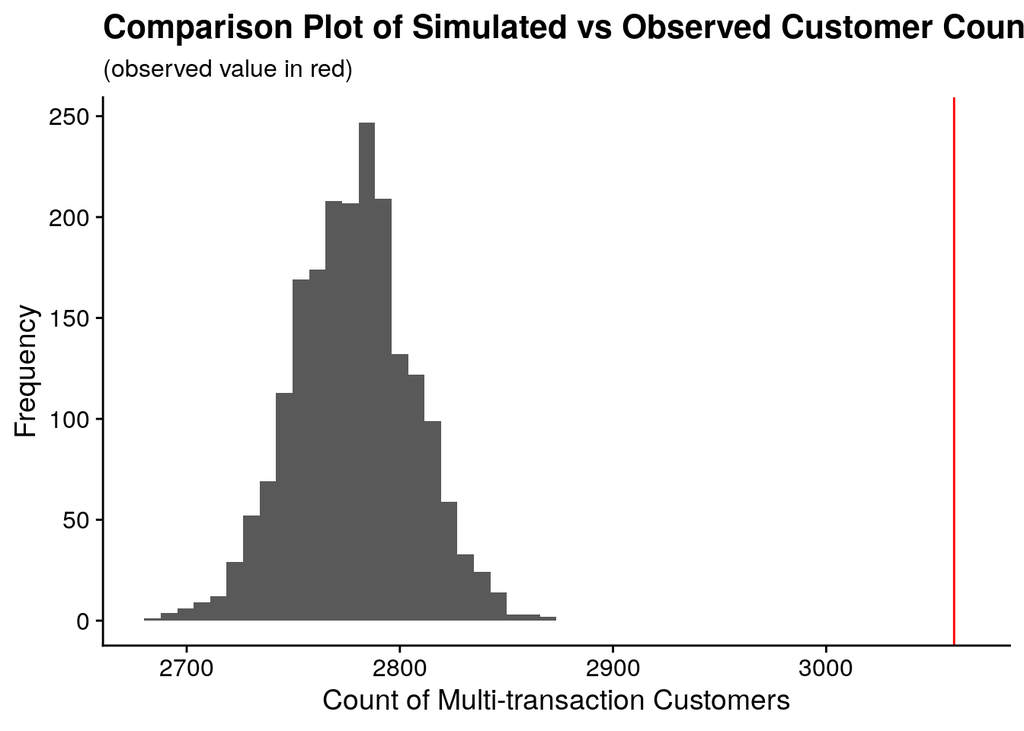

```r
insample_plots_lst <- create_model_assessment_plots(
  obsdata_tbl = obs_fitdata_tbl,
  simdata_tbl = assess_data_lst$model_fit_simstats_tbl
  )

insample_plots_lst$multi_plot |> print()
```

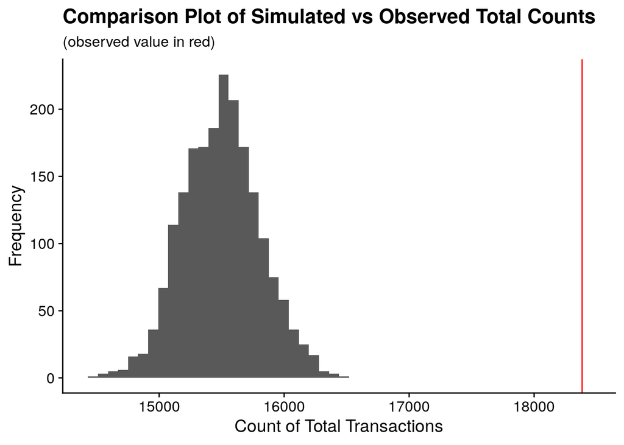

```r
insample_plots_lst$total_plot |> print()
```

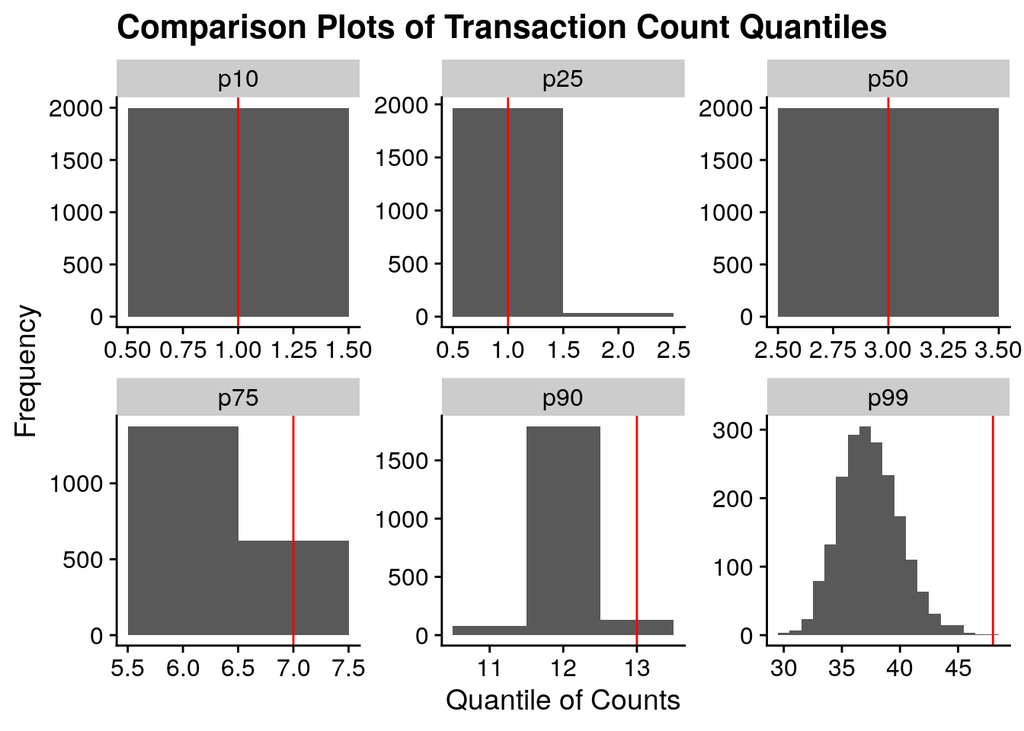

```r
insample_plots_lst$quant_plot |> print()
```

### 2.3.2 Check Out-of-Sample Data Validation

We now repeat for the out-of-sample data.

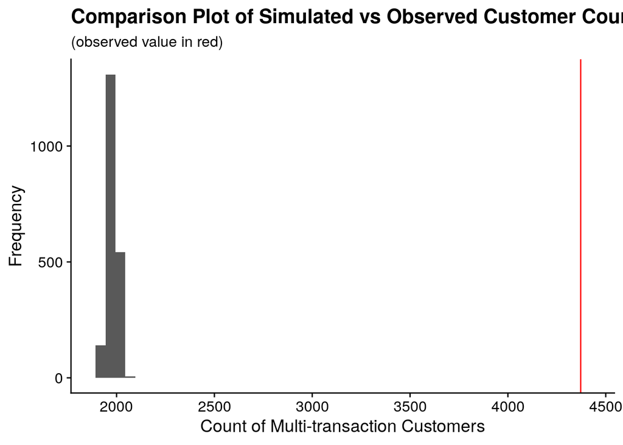

```r
outsample_plots_lst <- create_model_assessment_plots(
  obsdata_tbl = obs_validdata_tbl,
  simdata_tbl = assess_data_lst$model_valid_simstats_tbl
  )

outsample_plots_lst$multi_plot |> print()
```

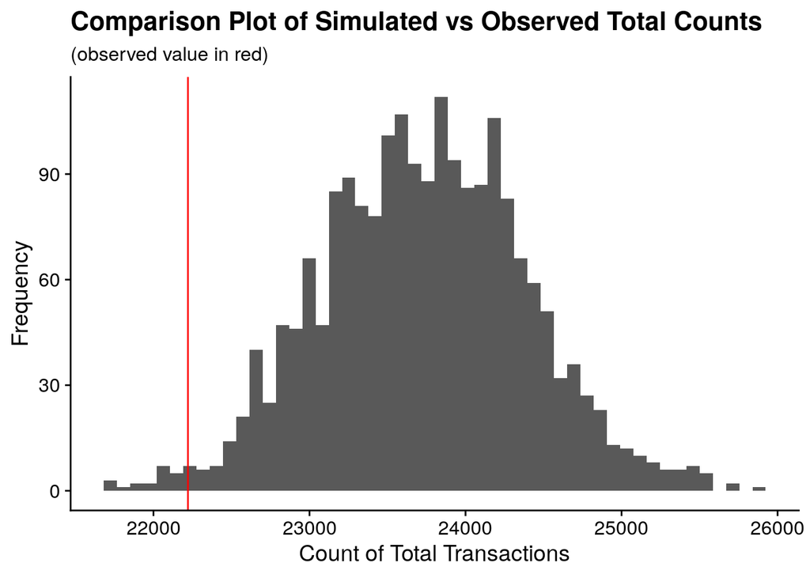

```r
outsample_plots_lst$total_plot |> print()
```

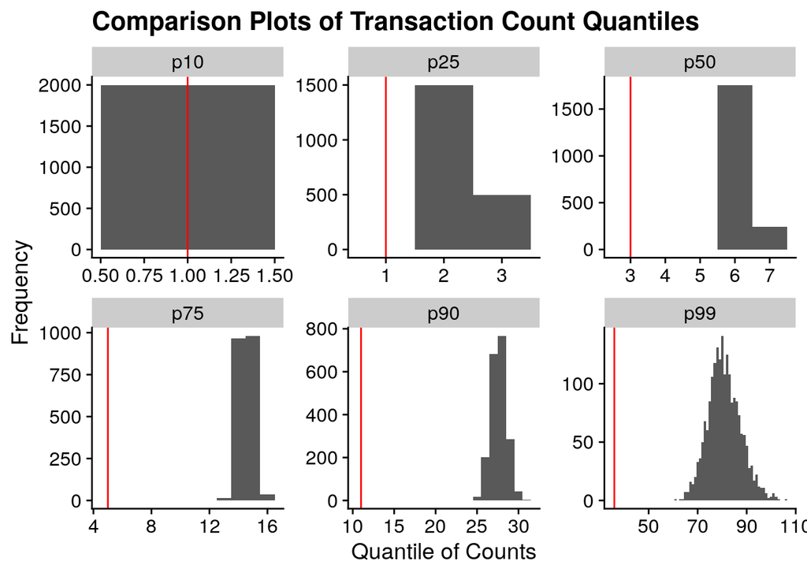

```r
outsample_plots_lst$quant_plot |> print()
```

## 2.4 Write Assess Data to Disk

We now store this assessment data to disk.

```r
assess_data_lst$model_simstats_tbl |>
  write_rds("data/pnbd_onlineretail_fixed1_assess_model_simstats_tbl.rds")

assess_data_lst$model_fit_simstats_tbl |>
  write_rds("data/pnbd_onlineretail_fixed1_assess_fit_simstats_tbl.rds")

assess_data_lst$model_valid_simstats_tbl |>
  write_rds("data/pnbd_onlineretail_fixed1_assess_valid_simstats_tbl.rds")

rm(assess_data_lst)
gc()
```

```
            used    (Mb) gc trigger    (Mb)  max used    (Mb)
Ncells 229317970 12247.0  481021448 25689.4 253581462 13542.8
Vcells 505945572  3860.1  981323775  7487.0 817703090  6238.6
```

# 3 Fit Alternate Prior Model.

We want to try an alternate prior model with a smaller co-efficient of variation to see what impact it has on our procedures.

```r
stan_modelname <- "pnbd_onlineretail_fixed2"
stanfit_seed   <- stanfit_seed + 1
stanfit_prefix <- str_c("fit_", stan_modelname)

stanfit_object_file <- glue("data/{stanfit_prefix}_stanfit.rds")

stan_data_lst <- customer_fit_stats_tbl |>
  select(customer_id, x, t_x, T_cal) |>
  compose_data(
    lambda_mn = 0.25,
    lambda_cv = 0.50,

    mu_mn     = 0.10,
    mu_cv     = 0.50,
    )

if(!file_exists(stanfit_object_file)) {
  pnbd_onlineretail_fixed2_stanfit <- pnbd_fixed_stanmodel$sample(
    data            =                stan_data_lst,
    chains          =                            4,
    iter_warmup     =                          500,
    iter_sampling   =                          500,
    seed            =                 stanfit_seed,
    save_warmup     =                         TRUE,
    output_dir      =                stan_modeldir,
    output_basename =               stanfit_prefix,
    )

  pnbd_onlineretail_fixed2_stanfit$save_object(stanfit_object_file)

} else {
  pnbd_onlineretail_fixed2_stanfit <- read_rds(stanfit_object_file)
}
```

[output not shown]

```r
pnbd_onlineretail_fixed2_stanfit$summary()
```

```
# A tibble: 13,009 × 10
   variable       mean   median      sd     mad       q5      q95  rhat ess_bulk
   <chr>         <num>    <num>   <num>   <num>    <num>    <num> <num>    <num>
 1 lp__       -1.53e+5 -1.53e+5 68.9    69.7    -1.53e+5 -1.53e+5 1.00      709.
 2 lambda[1]   2.90e-1  2.85e-1  0.0676  0.0689  1.87e-1  4.09e-1 1.00     4257.
 3 lambda[2]   2.11e-1  1.91e-1  0.109   0.0972  7.33e-2  4.27e-1 1.00     3812.
 4 lambda[3]   2.09e-1  1.89e-1  0.110   0.0975  6.67e-2  4.19e-1 1.00     4152.
 5 lambda[4]   1.04e-1  9.86e-2  0.0387  0.0367  4.75e-2  1.75e-1 1.00     4541.
 6 lambda[5]   2.48e-1  2.28e-1  0.121   0.113   8.50e-2  4.76e-1 1.01     2927.
 7 lambda[6]   2.69e-1  2.54e-1  0.119   0.117   1.06e-1  4.84e-1 0.999    3771.
 8 lambda[7]   2.07e-1  1.90e-1  0.106   0.0988  6.96e-2  4.00e-1 1.01     2248.
 9 lambda[8]   2.09e-1  1.90e-1  0.113   0.100   6.08e-2  4.30e-1 1.00     3469.
10 lambda[9]   2.57e-1  2.44e-1  0.101   0.0988  1.16e-1  4.43e-1 1.01     4134.
# ℹ 12,999 more rows
# ℹ 1 more variable: ess_tail <num>
```

We have some basic HMC-based validity statistics we can check.

```r
pnbd_onlineretail_fixed2_stanfit$cmdstan_diagnose()
```

```
Processing csv files: /home/rstudio/btydwork/stan_models/fit_pnbd_onlineretail_fixed2-1.csvWarning: non-fatal error reading adaptation data
, /home/rstudio/btydwork/stan_models/fit_pnbd_onlineretail_fixed2-2.csvWarning: non-fatal error reading adaptation data
, /home/rstudio/btydwork/stan_models/fit_pnbd_onlineretail_fixed2-3.csvWarning: non-fatal error reading adaptation data
, /home/rstudio/btydwork/stan_models/fit_pnbd_onlineretail_fixed2-4.csvWarning: non-fatal error reading adaptation data


Checking sampler transitions treedepth.
Treedepth satisfactory for all transitions.

Checking sampler transitions for divergences.
No divergent transitions found.

Checking E-BFMI - sampler transitions HMC potential energy.
E-BFMI satisfactory.

Effective sample size satisfactory.

Split R-hat values satisfactory all parameters.

Processing complete, no problems detected.
```

## 3.1 Visual Diagnostics of the Sample Validity

Now that we have a sample from the posterior distribution we need to create a few different visualisations of the diagnostics.

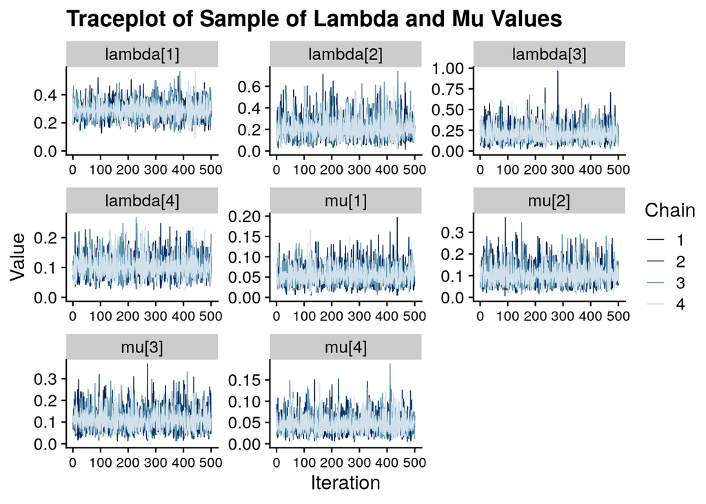

```r
parameter_subset <- c(
  "lambda[1]", "lambda[2]", "lambda[3]", "lambda[4]",
  "mu[1]",     "mu[2]",     "mu[3]",     "mu[4]"
  )

pnbd_onlineretail_fixed2_stanfit$draws(inc_warmup = FALSE) |>
  mcmc_trace(pars = parameter_subset) +
  expand_limits(y = 0) +
  labs(
    x = "Iteration",
    y = "Value",
    title = "Traceplot of Sample of Lambda and Mu Values"
    ) +
  theme(axis.text.x = element_text(size = 10))
```

We want to check the $N_{eff}$ statistics also.

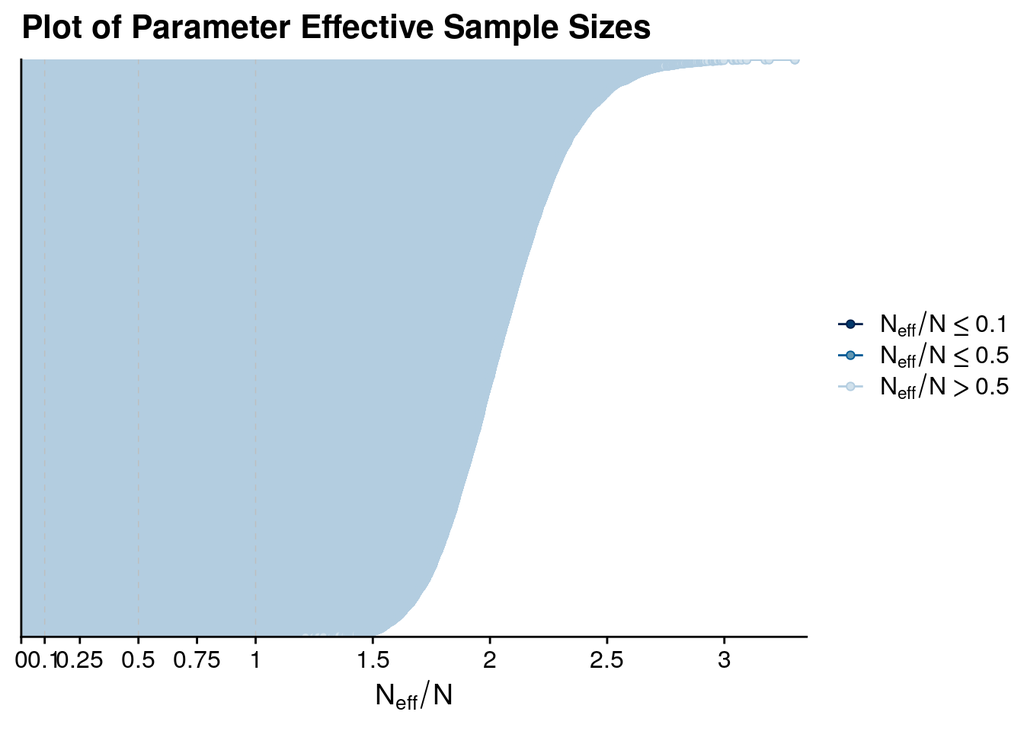

```r
pnbd_onlineretail_fixed2_stanfit |>
  neff_ratio(pars = c("lambda", "mu")) |>
  as.numeric() |>
  mcmc_neff() +
    ggtitle("Plot of Parameter Effective Sample Sizes")
```

## 3.2 Assess the Model

As we intend to run the same logic to assess each of our models, we have combined all this logic into a single function `run_model_assessment`, to run the simulations and combine the datasets.

```r
assess_data_lst <- run_model_assessment(
  model_stanfit    = pnbd_onlineretail_fixed2_stanfit,
  insample_tbl     = customer_fit_stats_tbl,
  outsample_tbl    = customer_valid_stats_tbl,
  fit_label        = "pnbd_onlineretail_fixed2",
  fit_end_dttm     = use_fit_end_date     |> as.POSIXct(),
  valid_start_dttm = use_valid_start_date |> as.POSIXct(),
  valid_end_dttm   = use_valid_end_date   |> as.POSIXct(),
  sim_seed         = 20
  )

assess_data_lst |> glimpse()
```

```
List of 3
 $ model_simstats_tbl      : tibble [8,672,000 × 6] (S3: tbl_df/tbl/data.frame)
  ..$ customer_id   : chr [1:8672000] "12346" "12346" "12346" "12346" ...
  ..$ first_tnx_date: POSIXct[1:8672000], format: "2009-12-14 08:34:00" "2009-12-14 08:34:00" ...
  ..$ draw_id       : int [1:8672000] 1 2 3 4 5 6 7 8 9 10 ...
  ..$ post_lambda   : num [1:8672000] 0.342 0.414 0.304 0.233 0.324 ...
  ..$ post_mu       : num [1:8672000] 0.0685 0.0811 0.0588 0.0642 0.0285 ...
  ..$ p_alive       : num [1:8672000] 0.1775 0.0975 0.2503 0.3084 0.4225 ...
 $ model_fit_simstats_tbl  : tibble [8,672,000 × 5] (S3: tbl_df/tbl/data.frame)
  ..$ customer_id  : chr [1:8672000] "12346" "12346" "12346" "12346" ...
  ..$ draw_id      : int [1:8672000] 1 2 3 4 5 6 7 8 9 10 ...
  ..$ sim_data     :List of 8672000
  ..$ sim_tnx_count: int [1:8672000] 0 2 15 11 0 5 5 11 3 1 ...
  ..$ sim_tnx_last : POSIXct[1:8672000], format: NA "2009-12-29 09:07:04" ...
 $ model_valid_simstats_tbl: tibble [8,672,000 × 5] (S3: tbl_df/tbl/data.frame)
  ..$ customer_id  : chr [1:8672000] "12346" "12346" "12346" "12346" ...
  ..$ draw_id      : int [1:8672000] 1 2 3 4 5 6 7 8 9 10 ...
  ..$ sim_data     :List of 8672000
  ..$ sim_tnx_count: int [1:8672000] 22 0 0 0 0 0 3 0 0 0 ...
  ..$ sim_tnx_last : POSIXct[1:8672000], format: "2012-05-06 00:02:14" NA ...
```

### 3.2.1 Check In-Sample Data Validation

We first check the model against the in-sample data.

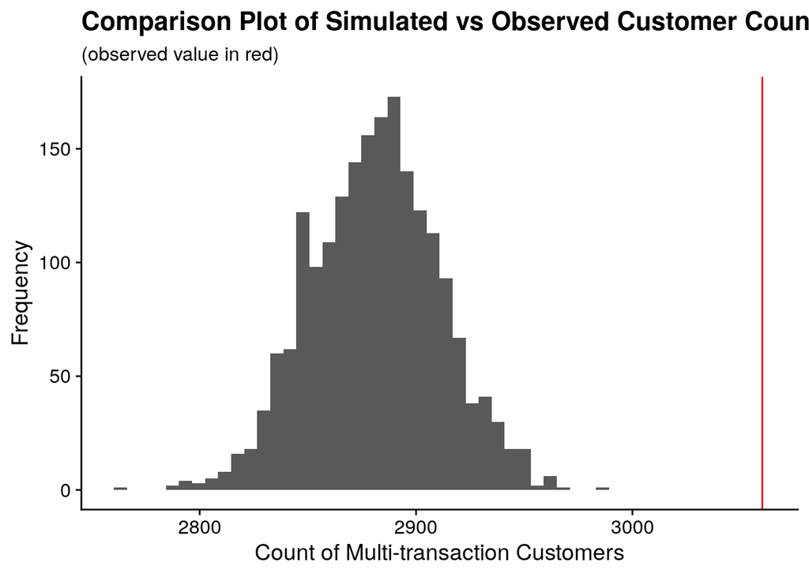

```r
insample_plots_lst <- create_model_assessment_plots(
  obsdata_tbl = obs_fitdata_tbl,
  simdata_tbl = assess_data_lst$model_fit_simstats_tbl
  )

insample_plots_lst$multi_plot |> print()
```

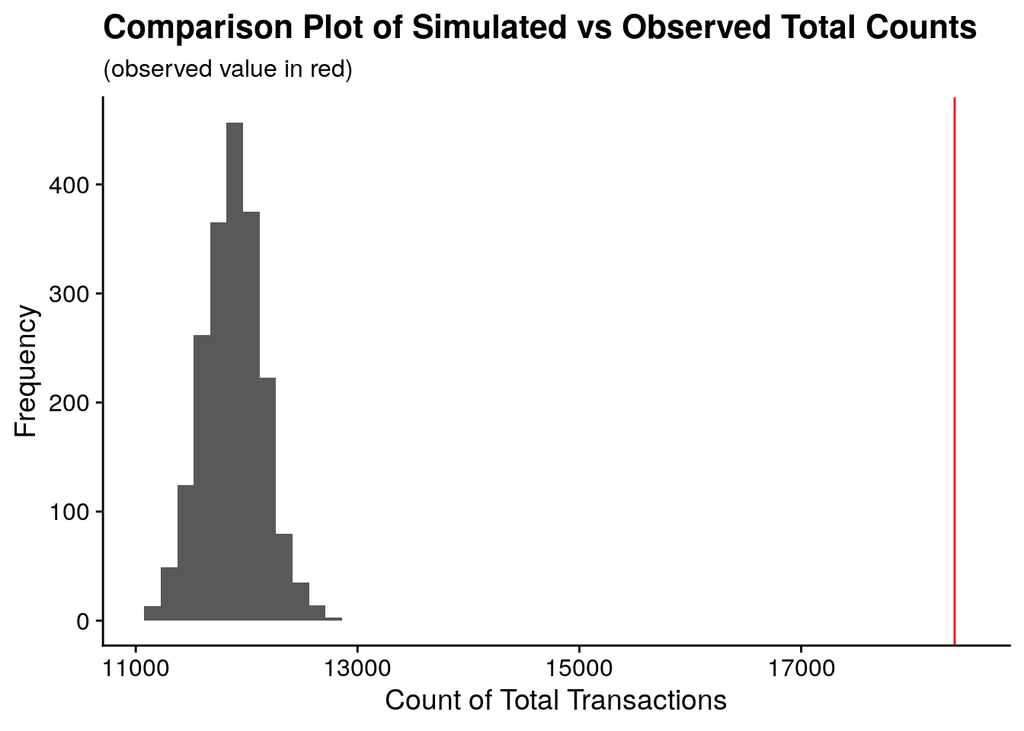

```r
insample_plots_lst$total_plot |> print()
```

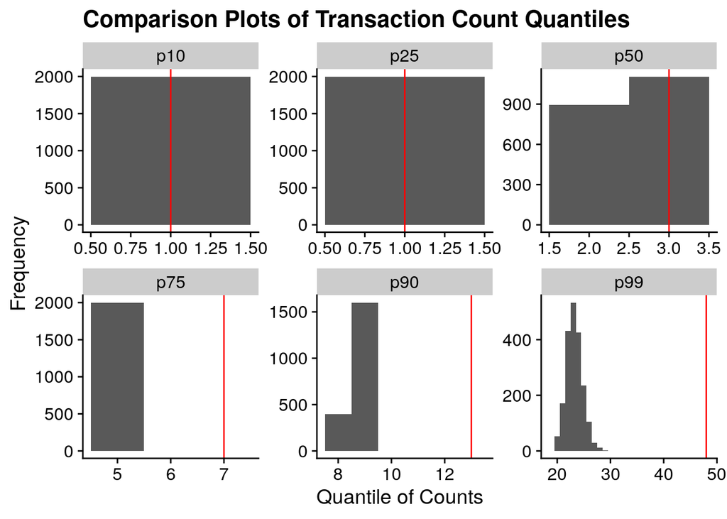

```r
insample_plots_lst$quant_plot |> print()
```

### 3.2.2 Check Out-of-Sample Data Validation

We now repeat for the out-of-sample data.

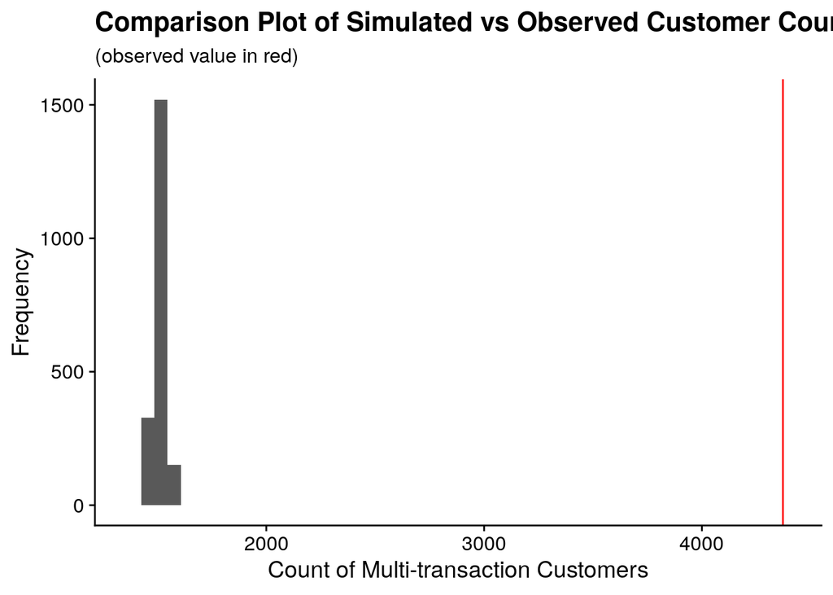

```r
outsample_plots_lst <- create_model_assessment_plots(
  obsdata_tbl = obs_validdata_tbl,
  simdata_tbl = assess_data_lst$model_valid_simstats_tbl
  )

outsample_plots_lst$multi_plot |> print()
```

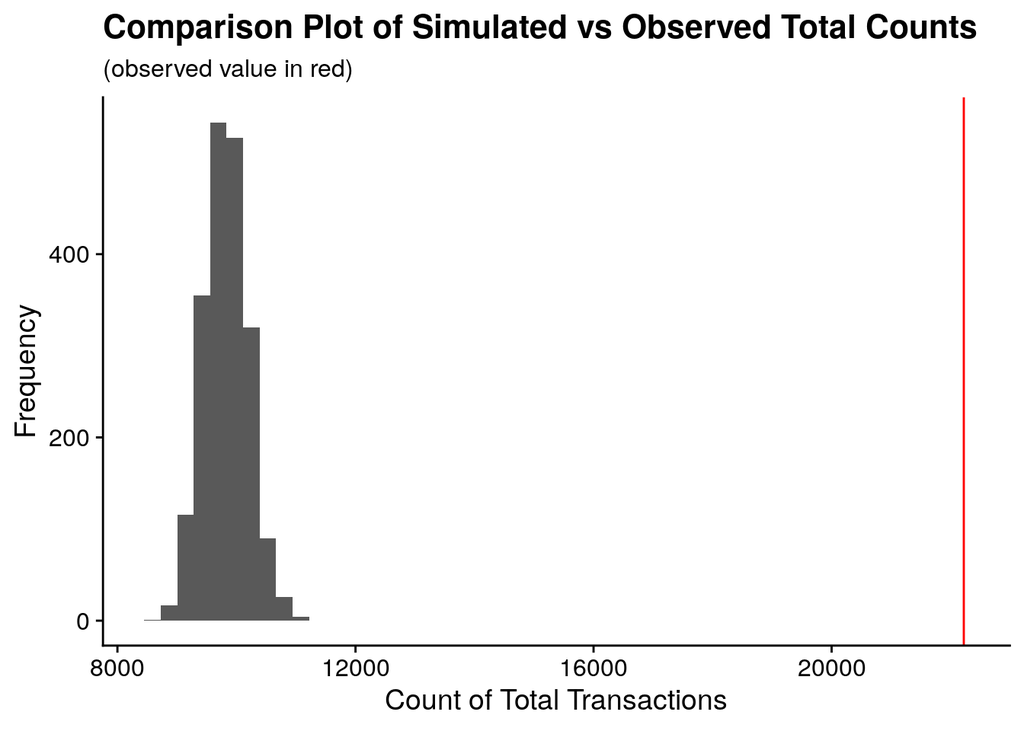

```r
outsample_plots_lst$total_plot |> print()
```

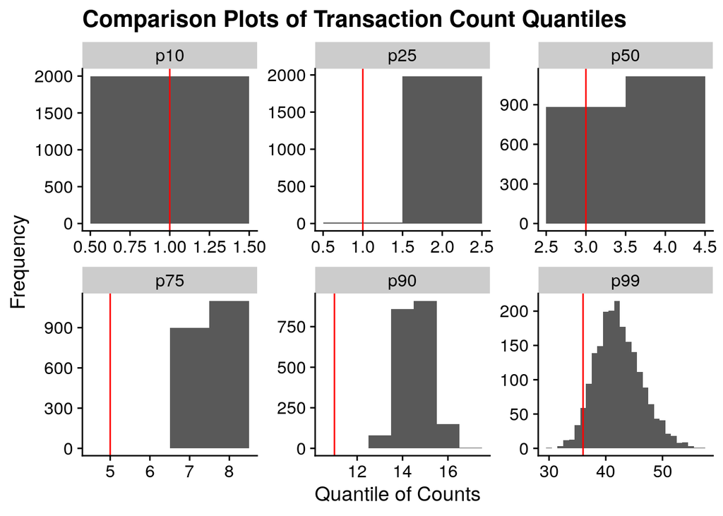

```r
outsample_plots_lst$quant_plot |> print()
```

## 3.3 Write Assess Data to Disk

We now store this assessment data to disk.

```r
assess_data_lst$model_simstats_tbl |>
  write_rds("data/pnbd_onlineretail_fixed2_assess_model_simstats_tbl.rds")

assess_data_lst$model_fit_simstats_tbl |>
  write_rds("data/pnbd_onlineretail_fixed2_assess_fit_simstats_tbl.rds")

assess_data_lst$model_valid_simstats_tbl |>
  write_rds("data/pnbd_onlineretail_fixed2_assess_valid_simstats_tbl.rds")

rm(assess_data_lst)
gc()
```

```
            used    (Mb) gc trigger    (Mb)   max used    (Mb)
Ncells 229348470 12248.6  653857944 34919.8  516971851 27609.3
Vcells 483146440  3686.2 1413282236 10782.5 1399647440 10678.5
```

```r
knitr::knit_exit()
```